# Uso do pacote `{fluxus}`

```r
suppressPackageStartupMessages({
  library(fluxus)
  library(dplyr)
  library(readxl)
  library(tidyr)
  library(stringr)
})
```

# Introdução

O objetivo deste tutorial é mostrar como as funções até o momento implementadas no pacote `{fluxus}` podem ser utilizadas para que possam ser objeto de críticas e sugestões de molhoria.

O pacote está disponível no GitHub https://github.com/marcosfs2006/fluxus e a instalação deve ser feita da seguinte forma:

```r
# install.packages("devtools")
devtools::install_github("marcosfs2006/fluxus")
library(fluxus)
```

Com esses comandos o pacote deve ser instalado e carregado.

A figura a seguir mostra o que já foi iniciado e o que ainda está pendente de realização no que diz respeito às funções do pacote dedicadas à criação de fluxos atuariais.

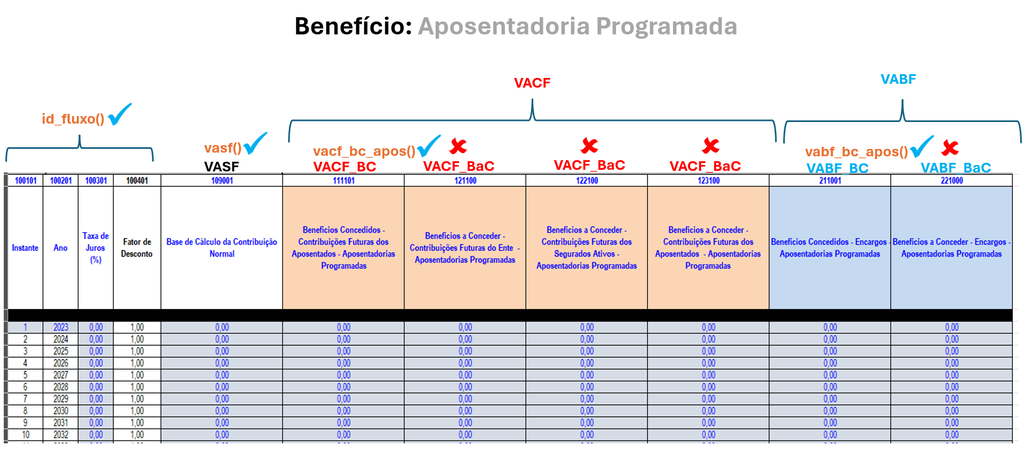

# Objetivo geral do pacote

O objetivo das funções até o momento implementadas, e do pacote de forma geral, é fornecer um conjunto de funções que facilitem a análise de fluxos atuariais dos RPPS e também permita a elaboração dos fluxos atuariais ao menos para algumas rubricas.

Até o momento, poucas funções foram implmentadaspermitindo que apenas um conjunto restrito de operações sejam realizadas. Com o tempo objetiva-se aumentar o leque de funções de forma que seja possível gerar a maioria das rubricas do fluxo atuarial dos RPPS conforme modelo disponibilizado pelo Ministério da Previdência Social - MPS e também mais funções dedicadas à análise dos fluxos.

O pacote utiliza extensivamente funções dos pacotes [`{lifecontingencies}`](https://cran.r-project.org/web/packages/lifecontingencies/index.html) e [`{tidyverse}`](https://www.tidyverse.org/) e até o momento disponibiliza dois conjuntos de funções: um para auxiliar na **análise** dos fluxos atuariais e outro para **gerar** o fluxo atuarial de algumas rubricas do modelo de fluxo atuarial do MPS.

# Funções para análise do fluxo atuarial:

Para a *análise* do fluxo atuarial até o momento já foram elaboradas as seguintes funções:

### `importa_fluxo()`

Esta função faz a importação dos dados contidos nos arquivos `csv` do fluxo atuarial. Para o seu correto funcionamento é fundamental que o arquivo esteja estritamente no formato disponibilizado e exigido pelo MPS.

### `extrai_resultados()`

Esta função calcula o VPA (valor presente atuarial) de algumas quantidades atuariais.

No momento, a função retorna o VPA das seguintes quantidades atuariais: `vasf`, `vabf`, `vacf`,`vabf_bc`,`vabf_bac`, `vacf_bc`, `vacf_bac`, `rm_bc`, `rm_bac`, `ag`, `ra` e `rm`

### `plota_fluxo()`

Esta função permite a elaboração de gráficos de linha mostrando a evolução temporal da quantidade atuarial escolhida dentre aquelas mencionadas no tópico anterior.

No momento a função só suporta a realização do gráfico de apenas uma quantidade atuarial. Objetiva-se aperfeiçoar a função para que possa “plotar” mais de uma quantidade atual no mesmo gráfico facilitando a comparação de fluxos.

Por ora essas são as três funções disponibilizadas pelo pacote para auxiliar na análise do fluxo atuarial. As funções ainda estão numa fase bem inicial de desenvolvimento e serão aperfeiçoadas com o tempo à medida que forem sendo testadas, bem como outras funções poderão vir a ser adicionadas.

# Funções para elaboração do fluxo atuarial:

Para a *elaboração* do fluxo atuarial, até o momento já estão “prontas” as funções a seguir elencadas:

### `id_fluxo()`

Esta função produz as quatro primeiras colunas do fluxo atuarial que correspondem às rubricas `100101 (Instante)`, `100201 (Ano)`, `100301 (Taxa de Juros %)` e `100401 (Fator de Desconto)`

### `vasf()`

Esta função produz o fluxo atuarial relativo à folha de contribuições futuras. Corresponde à rubrica `109001 (Base de Cálculo da Contribuição Normal)`

### `vabf_bc_apos()`

Esta função produz o fluxo atuarial dos encargos de benefícios futuros (benefício concedido) para o benefício de aposentadoria programada. Corresponde à rubrica `211001 (Benefícios Concedidos - Encargos - Aposentadorias Programadas)`

## Funções auxiliares:

Além das funções principais, acima elencadas, que produzem diretamente o fluxo atuarial, foram desenvolvidas funções auxiliares que, ou produzem resultados que são fornecidos às funções principais acima elencadas como argumentos, ou são por elas utilizadas internamente e não são disponibilizadas aos usuários.

Essas funções são as seguintes:

- `calcula_fator_capacidade()` - calcula o fator de capacidade
- `calcula_multidecremento()` - calcula probabilidades multidecrementais
- `calcula_taxa_conjugada()` - calcula taxa conjugada
- `cria_comutacao()` - cria um objeto `actuarialtable` do pacote `{lifecontingencies}`
- `cria_tabua()` - cria um objeto `lifetable` do pacote `{lifecontingencies}`
- `Calcula_Sproj()` - chamada internamente - calcula projeções salariais
- `get_Ex()` - chamada internamente - calcula fatores de desconto atuariais
- `get_pxT()` - chamada internamente - calcula probabilidades de sobrevivência

# Exemplos de Uso das Funções de Análise do Fluxo Atuarial

Para ilustrar o uso dessa funções será utilizado um fluxo atuarial real de um RPPS fluminense. O fluxo atuarial está contido no arquivo `FluxoAtuarial_1.csv`

## Importação do fluxo atuarial

O primeiro passo para a análise do fluxo atuarial em questão é realizar sua importação:

```r
flxRPPS_Fluminense <- importa_fluxo("FluxoAtuarial_1.csv")
```

```r
head(flxRPPS_Fluminense)
```

```
# A tibble: 6 × 67
  V100101 V100201 V100301 V100401   V109001 V111000 V111101 V111201 V111301
    <dbl>   <dbl>   <dbl>   <dbl>     <dbl>   <dbl>   <dbl>   <dbl>   <dbl>
1       1    2023    5.07   0.952 20519351.       0       0       0       0
2       2    2024    5.07   0.906 20674238.       0       0       0       0
3       3    2025    5.07   0.862 20835289.       0       0       0       0
4       4    2026    5.07   0.821 20805377.       0       0       0       0
5       5    2027    5.07   0.781 20585144.       0       0       0       0
6       6    2028    5.07   0.743 20320133.       0       0       0       0
# ℹ 58 more variables: V111401 <dbl>, V112000 <dbl>, V119900 <dbl>,
#   V121000 <dbl>, V121100 <dbl>, V121200 <dbl>, V121300 <dbl>, V121400 <dbl>,
#   V121500 <dbl>, V121600 <dbl>, V121700 <dbl>, V122000 <dbl>, V122100 <dbl>,
#   V122200 <dbl>, V122300 <dbl>, V122400 <dbl>, V122500 <dbl>, V122600 <dbl>,
#   V122700 <dbl>, V123000 <dbl>, V123100 <dbl>, V123200 <dbl>, V123300 <dbl>,
#   V123400 <dbl>, V124000 <dbl>, V124100 <dbl>, V124200 <dbl>, V124300 <dbl>,
#   V124400 <dbl>, V124500 <dbl>, V129000 <dbl>, V130101 <dbl>, …
```

```r
glimpse(flxRPPS_Fluminense)
```

```
Rows: 150
Columns: 67
$ V100101 <dbl> 1, 2, 3, 4, 5, 6, 7, 8, 9, 10, 11, 12, 13, 14, 15, 16, 17, 18,…
$ V100201 <dbl> 2023, 2024, 2025, 2026, 2027, 2028, 2029, 2030, 2031, 2032, 20…
$ V100301 <dbl> 5.07, 5.07, 5.07, 5.07, 5.07, 5.07, 5.07, 5.07, 5.07, 5.07, 5.…
$ V100401 <dbl> 0.95175, 0.90582, 0.86211, 0.82051, 0.78092, 0.74324, 0.70738,…
$ V109001 <dbl> 20519351, 20674238, 20835289, 20805377, 20585144, 20320133, 19…
$ V111000 <dbl> 0, 0, 0, 0, 0, 0, 0, 0, 0, 0, 0, 0, 0, 0, 0, 0, 0, 0, 0, 0, 0,…
$ V111101 <dbl> 0, 0, 0, 0, 0, 0, 0, 0, 0, 0, 0, 0, 0, 0, 0, 0, 0, 0, 0, 0, 0,…
$ V111201 <dbl> 0, 0, 0, 0, 0, 0, 0, 0, 0, 0, 0, 0, 0, 0, 0, 0, 0, 0, 0, 0, 0,…
$ V111301 <dbl> 0, 0, 0, 0, 0, 0, 0, 0, 0, 0, 0, 0, 0, 0, 0, 0, 0, 0, 0, 0, 0,…
$ V111401 <dbl> 0, 0, 0, 0, 0, 0, 0, 0, 0, 0, 0, 0, 0, 0, 0, 0, 0, 0, 0, 0, 0,…
$ V112000 <dbl> 0, 0, 0, 0, 0, 0, 0, 0, 0, 0, 0, 0, 0, 0, 0, 0, 0, 0, 0, 0, 0,…
$ V119900 <dbl> 235291.85, 235291.85, 235291.85, 235291.85, 235101.23, 235016.…
$ V121000 <dbl> 1846742.5, 1860680.8, 1875175.4, 1872484.6, 1852660.0, 1828812…
```

[output cut: 54 more lines]

## Extração do VPA de algumas quantidades atuariais

Para extrair o VPA utiliza-se a função `extrai_resultados()`. Ela recebe como argumento o fluxo acima importado e a quantidade atuarial para a qual se quer obter o VPA dentre aquelas já acima mencionadas. Exemplos:

VPA da Reserva Matemática (`rm`)

```r
extrai_resultados(flxRPPS_Fluminense, tipo="rm")
```

```
$rm
[1] 60844888
```

Saldo do Ativo Garantidor (`ag`) e VPA do VABF BaC (`vabf_bac`)

```r
extrai_resultados(flxRPPS_Fluminense, tipo=c("ag", "vabf_bac"))
```

```
$ag
[1] 53456982

$vabf_bac
[1] 85387764
```

Se não for especificado o argumento `tipo=` a função retorna o VPA de todas as quantidades atuariais:

```r
extrai_resultados(flxRPPS_Fluminense)
```

```
$vasf
[1] 253234530

$vabf
[1] 128038776

$vacf
[1] 67193888

$vabf_bc
[1] 42651011

$vabf_bac
[1] 85387764

$vacf_bc
[1] 2981322

$vacf_bac
[1] 64212565

$rm_bc
[1] 39669689

$rm_bac
[1] 21175199

$ag
[1] 53456982

$ra
[1] -7387906

$rm
[1] 60844888
```

Ainda falta documentar a função para explicitar quais rubricas estão sendo condideradas para gerar as quantidades atuariais acima elencadas.

## Análise gráfica

Para verificar a evolução temporal de qualquer uma das quantidades atuariais acima elencadas utiliza-se a função `plota_fluxo()`. Exemplo:

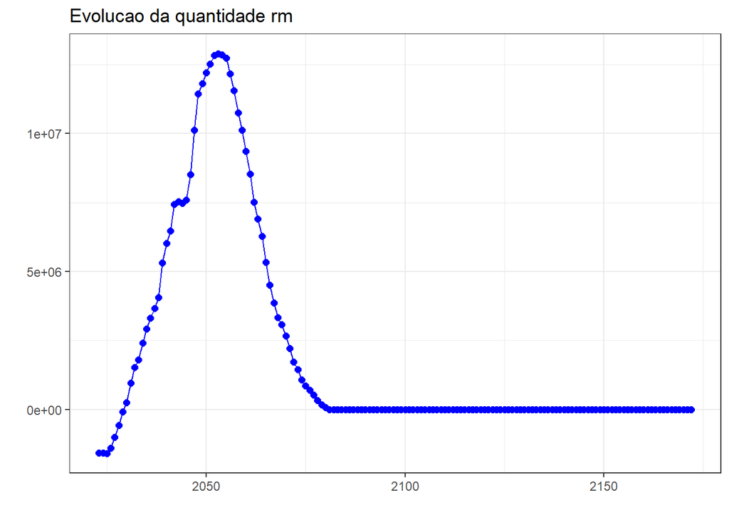

```r
plota_fluxo(flxRPPS_Fluminense)
```

Por *default* a função gera o gráfico da Reserva Matemática (`rm`).

Para “plotar” outra quantidade basta especificar qual quantidade desejada no argumento `tipo=`. Para o gráfico do VABF:

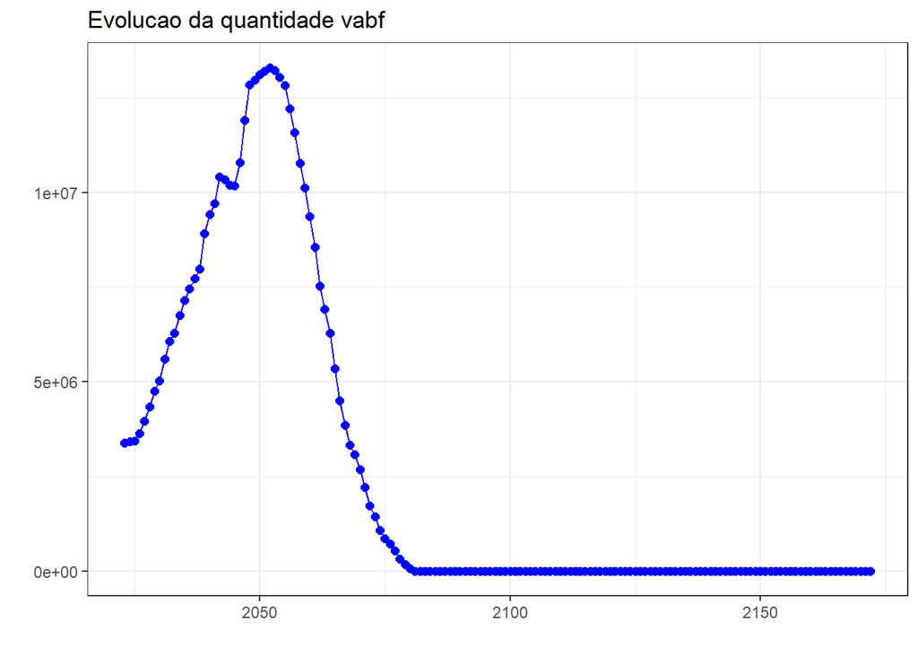

```r
plota_fluxo(flxRPPS_Fluminense, tipo = "vabf")
```

# Exemplos de Uso das Funções de Geração do Fluxo Atuarial

Para ilustrar o uso das funções de produção de fluxo atuarial acima elencadas, serão definidos arbitrariamente alguns parâmetros a serem considerados.

Estas funções foram desenvolvidas tendo em mente que a base de dados cadastral fornecerá parte dos *inputs* necessários para o uso das funções e a outra parte virá dos parâmetros oriundos das bases técnicas (premissas atuariais) e normativa adotados para a realização da avaliação atuarial.

Os parâmetros são:

- Taxa de juros: 4,93% a.a.
- Taxa real de crescimento dos benefícios: 0%
- Taxa real de crescimento dos salários: 1%
- Inflação de longo prazo: 4,5%
- Data focal da avaliação: 31/12/2022
- Quantidades de pagamentos no ano: 13
- Teto de benefícios do RGPS: R$ 7.507,49
- Alíquota de contribuição do aposentado: 14%
- Rotatividade: 1%
- Tábua de Mortalidade Geral: IBGE 2021
- Tábua de Invalidez: Alvaro Vindas

Para facilitar o uso desses valores posteriormente será construída uma lista com todos os valores acima:

```r
parametros <- list(juros = 4.93,
                   cb = 0,
                   cs = 1,
                   inflacao = 4.5,
                   dt_focal = "31/12/2022",
                   qtd_pag_ano = 13,
                   tetoRGPS = 7507.49,
                   aliq_contr_apos = 14,
                   rotatividade = 1,
                   tmg = c("IBGE2021M", "IBGE2021F"),
                   tmi = "ALVARO.VINDAS")
```

## `id_fluxo()`

Esta função tem por finalidade gerar as quatro primeiras colunas do fluxo atuarial conforme modelo do Ministério da Previdência Social - MPS. Esta função recebe os parâmetros `dt_focal` e `juros`.

```r
id_fluxo(dt_focal=parametros[["dt_focal"]],
         juros = parametros[["juros"]]) %>%  head()
```

```
  V100101 V100201 V100301 V100401
1       1    2023    4.93 0.95302
2       2    2024    4.93 0.90824
3       3    2025    4.93 0.86557
4       4    2026    4.93 0.82490
5       5    2027    4.93 0.78614
6       6    2028    4.93 0.74921
```

```r
id_fluxo(dt_focal=parametros[["dt_focal"]],
         juros = parametros[["juros"]]) %>%  tail()
```

```
    V100101 V100201 V100301 V100401
145     145    2167    4.93 0.00093
146     146    2168    4.93 0.00089
147     147    2169    4.93 0.00085
148     148    2170    4.93 0.00081
149     149    2171    4.93 0.00077
150     150    2172    4.93 0.00073
```

## `cria_tabua()` e `cria_comutação()`

Antes de exemplificar o uso das demais funções, será mostrado como criar os objetos das classes `lifetable` e `actuarialtable` do pacote `lifecontingencies` que serão utilizados nas funções que se seguem.

Visando facilitar o uso das funções disponibilizadas no pacote `{lifecontingencies}` que criam os objetos acima mencionados, o pacote `{fluxus}` disponibiliza duas funções para criar esses objetos de forma mais simples, as funções `cria_tabua()` e `cria_comutacao()`.

A função `cria_tabua()` gera um objeto da classe `lifetable` a partir do nome de uma tábua biométrica cadastrada no pacote passada como argumento.

A função obtém as probabilidades de morte ($q_x$) do data frame `tabuas` que é um conjunto de dados interno do pacote que contém o “cadastro” de diversas tábuas biométricas cujos nomes servem de argumento para essa função.

Já a função `cria_comutacao()` gera um objeto da classe `actuarialtable` a partir de um objeto da classe `lifetable` e de uma taxa de juros.

o data frame `tabuas` contém os dados das probabilidades de morte ($q_x$) de 62 tábuas biométricas. Com o tempo, outras serão disponibilizadas:

```r
head(tabuas)
```

```
# A tibble: 6 × 63
      x    AT49M    AT49F AT2000MBasic AT2000FBasic  AT2000M  AT2000F  RP2000M
  <dbl>    <dbl>    <dbl>        <dbl>        <dbl>    <dbl>    <dbl>    <dbl>
1     0 0.00404  0.00321      0.00231      0.00179  0.00208  0.00162  0
2     1 0.00158  0.00136      0.000906     0.000755 0.000815 0.00068  0.000637
3     2 0.000887 0.000703     0.000504     0.000392 0.000454 0.000353 0.00043
4     3 0.000715 0.000521     0.000408     0.00029  0.000367 0.000261 0.000357
5     4 0.000627 0.000419     0.000357     0.000232 0.000321 0.000209 0.000278
6     5 0.000566 0.000339     0.000324     0.000189 0.000291 0.000171 0.000255
# ℹ 55 more variables: RP2000F <dbl>, RP2000A <dbl>, BR.EMS2010M <dbl>,
#   BR.EMS2010F <dbl>, BR.EMS2015M <dbl>, BR.EMS2015F <dbl>, BR.EMS2021M <dbl>,
#   BR.EMS2021F <dbl>, IBGE2007A <dbl>, IBGE2008A <dbl>, IBGE2009A <dbl>,
#   IBGE2010M <dbl>, IBGE2010F <dbl>, IBGE2010A <dbl>, IBGE2011M <dbl>,
#   IBGE2011F <dbl>, IBGE2011A <dbl>, IBGE2012M <dbl>, IBGE2012F <dbl>,
#   IBGE2012A <dbl>, IBGE2013M <dbl>, IBGE2013F <dbl>, IBGE2013A <dbl>,
#   IBGE2014M <dbl>, IBGE2014F <dbl>, IBGE2014A <dbl>, IBGE2015M <dbl>, …
```

As tábuas até o momento cadastradas são as seguintes:

```r
names(tabuas)[-1]
```

```
 [1] "AT49M"         "AT49F"         "AT2000MBasic"  "AT2000FBasic"
 [5] "AT2000M"       "AT2000F"       "RP2000M"       "RP2000F"
 [9] "RP2000A"       "BR.EMS2010M"   "BR.EMS2010F"   "BR.EMS2015M"
[13] "BR.EMS2015F"   "BR.EMS2021M"   "BR.EMS2021F"   "IBGE2007A"
[17] "IBGE2008A"     "IBGE2009A"     "IBGE2010M"     "IBGE2010F"
[21] "IBGE2010A"     "IBGE2011M"     "IBGE2011F"     "IBGE2011A"
[25] "IBGE2012M"     "IBGE2012F"     "IBGE2012A"     "IBGE2013M"
[29] "IBGE2013F"     "IBGE2013A"     "IBGE2014M"     "IBGE2014F"
[33] "IBGE2014A"     "IBGE2015M"     "IBGE2015F"     "IBGE2015A"
[37] "IBGE2016M"     "IBGE2016F"     "IBGE2016A"     "IBGE2017M"
[41] "IBGE2017F"     "IBGE2017A"     "IBGE2018M"     "IBGE2018F"
[45] "IBGE2018A"     "IBGE2019M"     "IBGE2019F"     "IBGE2019A"
[49] "IBGE2020M"     "IBGE2020F"     "IBGE2020A"     "IBGE2021M"
[53] "IBGE2021F"     "IBGE2021A"     "IBGE2022M"     "IBGE2022F"
[57] "IBGE2022A"     "TASA1927"      "ALVARO.VINDAS" "HUNTERS"
[61] "LIGHT.FORTE"   "LIGHT.MEDIA"
```

Exemplo de criação das tábuas de comutação, usando como tábua de mortalidade a IBGE 2021 e taxa de juros de 4,93%:

```r
qx_msc <- cria_tabua("IBGE2021M") %>%
          cria_comutacao(juros=parametros[["juros"]])

qx_fem <- cria_tabua("IBGE2021M") %>%
          cria_comutacao(juros=parametros[["juros"]])
```

Futuramente a função `cria_comutacao()` pode ser melhorada para criar a tábua de comutação a partir do nome da tábua e da taxa de juros desejada: `cria_comutacao("IBGE2021M", 4.93)`.

```r
summary(qx_msc)
```

```
This is lifetable:  IBGE2021M
 Omega age is:  109
 Expected curtated lifetime at birth is:  73.06634 Interest rate used is: 0.0493
```

Às vezes será necessário criar tábuas com probabilidades multidecrementais as quais podem ser obtidas com a função `calcula_multidecremento()` e então serem passadas para a função `cria_tabua()`. No exemplo as seguir, cosidera-se três fatores decrementais: morte, invalidez e rotatividade:

```r
qxT_msc <- calcula_multidecremento(qx=tabuas$IBGE2021M,
                                   ix=tabuas$ALVARO.VINDAS,
                                   tx=parametros[["rotatividade"]] / 100)


qxT_fem <- calcula_multidecremento(qx=tabuas$IBGE2021F,
                                   ix=tabuas$ALVARO.VINDAS,
                                   tx=parametros[["rotatividade"]] / 100)
```

Os objetos `qxT_msc` e `qxT_fem` são vetores contendo as probabiliades multidecremenais. Estas agora podem ser passadas à função `cria_tabua()` para o cálculo de um objeto da classe `lifetable` com as probabilidades multidecrementais obtidas.

```r
tmdm <- cria_tabua(qxT_msc, md=TRUE)
tmdf <- cria_tabua(qxT_fem, md=TRUE)
```

```r
summary(tmdm)
```

```
This is lifetable:  Tabua de Multiplo Decremento
 Omega age is:  109
 Expected curtated lifetime at birth is:  47.94101
```

Deve ser observado agora o uso do argumento `md=TRUE`. Esse argumento foi criado para permitir a passagem à função de probabilidades que não viessem das tábuas já cadastradas que, como visto, passam os valores das probabilidades de morte pelo seu nome.

## `vasf()`

Vamos ilustrar o uso da função `vasf()` para o cálculo do fluxo atuarial relativo ao Valor Atual dos Salários de Contribuição Futuros - VASF

Para ilustar o uso da função será utilizada a base de dados `Base Dados para Estudo.xlsx` que possui dados para servidores ativo, aposentados e pensionistas.

Essa base de dados está disponível em https://github.com/marcosfs2006/elucubracoes_atuariais

Importação dos dados:

```r
ativos <- read_excel("Base Dados para Estudo.xlsx", sheet = "Ativos")
```

```r
head(ativos)
```

```
# A tibble: 6 × 6
     id dt_nascimento       dt_ingresso_servico_publico sexo  salario tipo_cargo
  <dbl> <dttm>              <dttm>                      <chr> <chr>        <dbl>
1     1 1977-08-25 00:00:00 2007-04-19 00:00:00         F     3491.86          2
2     2 1975-04-12 00:00:00 2002-03-01 00:00:00         M     5537.31          1
3     3 1970-09-20 00:00:00 2002-03-01 00:00:00         F     3493.91          1
4     4 1973-03-14 00:00:00 2009-03-23 00:00:00         F     4333.43          1
5     5 1982-01-23 00:00:00 2007-08-13 00:00:00         M     4499.74          1
6     6 1974-10-09 00:00:00 2007-08-20 00:00:00         M     3933.38          1
```

Importada a base de dados, o primeiro passo é realizar a análise da mesma e fazer os ajustes necessários, que inclui calcular novas colunas que se façam necessárias para o uso das funções. É o que será feito a seguir:

```r
ativos <- ativos %>%
  mutate(salario = as.numeric(salario),
         idade_prev_apos = if_else(sexo == "F", 60L, 65L),
         idade = calcula_idade(dt_nascimento, parametros[["dt_focal"]]))
```

```r
head(ativos)
```

```
# A tibble: 6 × 8
     id dt_nascimento       dt_ingresso_servico_publico sexo  salario tipo_cargo
  <dbl> <dttm>              <dttm>                      <chr>   <dbl>      <dbl>
1     1 1977-08-25 00:00:00 2007-04-19 00:00:00         F       3492.          2
2     2 1975-04-12 00:00:00 2002-03-01 00:00:00         M       5537.          1
3     3 1970-09-20 00:00:00 2002-03-01 00:00:00         F       3494.          1
4     4 1973-03-14 00:00:00 2009-03-23 00:00:00         F       4333.          1
5     5 1982-01-23 00:00:00 2007-08-13 00:00:00         M       4500.          1
6     6 1974-10-09 00:00:00 2007-08-20 00:00:00         M       3933.          1
# ℹ 2 more variables: idade_prev_apos <int>, idade <int>
```

No código acima foram criadas duas novas colunas: `idade_prev_apos` para indicar a idade prevista de aposentadoria. Arbitrariamente foi considerado que as mulheres se aposentam aos 60 anos e os homens aos 65.

Naturalmente que na prática esse cálculo irá requerer maiores considerações e provavelmente necessitará que a base cadastral contenha mais informações.

A outra coluna criada foi `idade` que mostra a idade do servidor na data da avaliação. Foi utilizada a função auxiliar `calcula_idade()` para a obtenção desses valores.

Agora já se tem os elementos necessários para utilizar a função `vasf()` para calcular o fluxo dos salários de contribuição futuros.

```r
flx_vasf <- vasf(Sx = ativos$salario,
                 idade = ativos$idade,
                 idade_prev_apos = ativos$idade_prev_apos,
                 sexo = ativos$sexo,
                 cs = parametros[["cs"]] / 100,
                 tmdm = tmdm,  # tábua multidecremental maculino
                 tmdf = tmdf)  # tábua multidecremental feminino
```

```r
head(flx_vasf)
```

```
  id    ano_1    ano_2    ano_3    ano_4    ano_5    ano_6    ano_7    ano_8
1  1 45235.64 45063.76 44877.66 44676.63 44459.68 44225.33 43971.79 43697.55
2  2 71517.73 71017.45 70481.37 69906.65 69290.27 68629.16 67920.07 67159.62
3  3 45137.56 44831.19 44499.70 44140.31 43750.59 43327.58 42868.39     0.00
4  4 56061.03 55765.53 55445.83 55100.03 54726.05 54321.40 53882.68 53406.94
5  5 58255.70 58002.39 57734.96 57451.44 57149.93 56828.56 56485.59 56118.91
6  6 50776.25 50392.96 49982.05 49541.34 49068.66 48561.67 48017.97 47434.49
     ano_9   ano_10   ano_11   ano_12   ano_13   ano_14   ano_15   ano_16
1 43400.96 43080.05 42732.12 42354.83 41945.31 41500.78     0.00     0.00
2 66343.55 65468.72 64531.72 63529.73 62459.13 61315.27 60092.70 58785.82
3     0.00     0.00     0.00     0.00     0.00     0.00     0.00     0.00
4 52890.57 52330.03     0.00     0.00     0.00     0.00     0.00     0.00
5 55726.35 55305.69 54854.72 54371.05 53852.29 53295.88 52699.17 52058.81
6 46809.00 46139.06 45422.65 44657.20 43839.36 42965.24 42030.84 41031.97
    ano_17   ano_18   ano_19   ano_20   ano_21   ano_22   ano_23   ano_24
```

[output cut: 97 more lines]

A função retorna um `data frame` contendo a mesma quantidade de linhas que a base de dados utilizada e 151 colunas. Para cada ano, tem-se a projeção salarial para cada servidor, até a data de aposentadoria.

Para sumarizar os dados a apresentá-los no formato do modelo do fluxo atuarial basta somar os valores e “pivotear” os dados.

```r
flx_vasf_resumo <- flx_vasf %>%
  summarise(across(starts_with("ano"), \(x) round(sum(x), 5))) %>%
  pivot_longer(everything(), names_to = "V100101", values_to="V109001") %>%
  mutate(V100101 = as.integer(str_extract(V100101, "\\d+$")))
```

```r
head(flx_vasf_resumo)
```

```
# A tibble: 6 × 2
  V100101   V109001
    <int>     <dbl>
1       1 92428120.
2       2 88160372.
3       3 83836256.
4       4 79901630.
5       5 75824899.
6       6 71457503.
```

```r
tail(flx_vasf_resumo)
```

```
# A tibble: 6 × 2
  V100101 V109001
    <int>   <dbl>
1     145       0
2     146       0
3     147       0
4     148       0
5     149       0
6     150       0
```

Como visto, a função `vasf()` retorna as projeções feitas para cada servidor. Será incluído um argumento que possibilitará ao usuário escolher entre retornar o fluxo já resumido, como feito acima ou retornar as projeções individuais, como implemenado até o momento.

## `vabf_bc_apos`

Esta função tem por objetivo calcular o fluxo fluturo dos benefícios concedidos relativos aos aposentados  
para o benefício de aposentadoria programada.

A função foi implementada considerando a possibilidade de que seja passada à função uma coluna da base cadastral contendo informações quanto ao `status` do aposentado, se válido ou inválido. A função, no momento, espera que os valores possíveis para essa coluna sejam, “V” ou “I”. Futuramente serão feitos ajustes para adotar o padrão dos modelos de base cadastral disponibilizados pelo MPS.

Também é possível passar uma coluna da base cadastral que contenha informações sobre a regra de benefício, se integralidade ou média.

```r
inativos <- read_excel("Base Dados para Estudo.xlsx", sheet = "Inativos")
```

```r
glimpse(inativos)
```

```
Rows: 577
Columns: 12
$ id                      <dbl> 1, 2, 3, 4, 5, 6, 7, 8, 9, 10, 11, 12, 13, 14,…
$ dt_nascimento           <dttm> 1943-01-25, 1951-01-20, 1956-09-05, 1946-02-0…
$ dt_inic_beneficio       <dttm> 1984-06-01, 1993-05-05, 1975-03-24, 2014-05-1…
$ dt_admissao             <dttm> 1984-06-01, 1993-05-05, 1975-03-24, 2014-05-1…
$ tipo_aposentadoria      <dbl> 1, 1, 1, 1, 1, 1, 1, 1, 4, 1, 1, 4, 4, 1, 1, 1…
$ insalubridade           <dbl> 0, 0, 0, 0, 0, 0, 0, 0, 0, 1, 0, 0, 0, 0, 1, 0…
$ vlr_beneficio           <chr> "937", "937", "7278.47", "2175.88", "11400.56"…
$ sexo                    <chr> "M", "F", "F", "F", "M", "F", "M", "F", "M", "…
$ doenca_incapacitante    <chr> "N", "N", "N", "N", "N", "N", "N", "N", "N", "…
$ plano                   <dbl> 1, 1, 1, 1, 1, 1, 1, 1, 1, 1, 1, 1, 1, 1, 1, 1…
$ tipo_cargo              <dbl> 1, 1, 1, 1, 1, 1, 1, 1, 1, 1, 1, 1, 1, 1, 1, 1…
$ tipo_reajuste_beneficio <dbl> 1, 1, 2, 1, 2, 1, 2, 2, 1, 2, 2, 1, 1, 2, 2, 2…
```

A partir dessa base de dados, algumas novas colunas precisam ser adicionadas:

```r
inativos <- inativos %>%
  mutate(vlr_beneficio = as.numeric(vlr_beneficio),
         idade = calcula_idade(dt_nascimento, parametros[["dt_focal"]]),
         base_calculo_contribuicao = if_else(vlr_beneficio < parametros[["tetoRGPS"]], 0, vlr_beneficio - parametros[["tetoRGPS"]]),
         vlr_contribuicao = base_calculo_contribuicao * parametros[["aliq_contr_apos"]] / 100,
         doenca_incapacitante = if_else(doenca_incapacitante == "S", "I", "V"),
         tipo_reajuste_beneficio = if_else(tipo_reajuste_beneficio %in% c(0, 2), "INTEGRALIDADE", "MEDIA"))
```

```r
glimpse(inativos)
```

```
Rows: 577
Columns: 15
$ id                        <dbl> 1, 2, 3, 4, 5, 6, 7, 8, 9, 10, 11, 12, 13, 1…
$ dt_nascimento             <dttm> 1943-01-25, 1951-01-20, 1956-09-05, 1946-02…
$ dt_inic_beneficio         <dttm> 1984-06-01, 1993-05-05, 1975-03-24, 2014-05…
$ dt_admissao               <dttm> 1984-06-01, 1993-05-05, 1975-03-24, 2014-05…
$ tipo_aposentadoria        <dbl> 1, 1, 1, 1, 1, 1, 1, 1, 4, 1, 1, 4, 4, 1, 1,…
$ insalubridade             <dbl> 0, 0, 0, 0, 0, 0, 0, 0, 0, 1, 0, 0, 0, 0, 1,…
$ vlr_beneficio             <dbl> 937.00, 937.00, 7278.47, 2175.88, 11400.56, …
$ sexo                      <chr> "M", "F", "F", "F", "M", "F", "M", "F", "M",…
$ doenca_incapacitante      <chr> "V", "V", "V", "V", "V", "V", "V", "V", "V",…
$ plano                     <dbl> 1, 1, 1, 1, 1, 1, 1, 1, 1, 1, 1, 1, 1, 1, 1,…
$ tipo_cargo                <dbl> 1, 1, 1, 1, 1, 1, 1, 1, 1, 1, 1, 1, 1, 1, 1,…
$ tipo_reajuste_beneficio   <chr> "MEDIA", "MEDIA", "INTEGRALIDADE", "MEDIA", …
$ idade                     <int> 79, 71, 66, 76, 69, 73, 74, 75, 69, 72, 68, …
$ base_calculo_contribuicao <dbl> 0.00, 0.00, 0.00, 0.00, 3893.07, 0.00, 0.00,…
$ vlr_contribuicao          <dbl> 0.0000, 0.0000, 0.0000, 0.0000, 545.0298, 0.…
```

No tratamento da base cadastral, foram adicionadas novas colunas e outras tiveram seus valores alterados para se conformar ao que a função espera receber.

O código a seguir ilustra o uso da função `vabf_bc()`:

```r
fluxo_vabf_bc <- vabf_bc_apos(Bx = inativos$vlr_beneficio,
                              inflacao = parametros[["inflacao"]],
                              juros = parametros[["juros"]],
                              idade = inativos$idade,
                              invalidez = inativos$doenca_incapacitante,
                              regra = inativos$tipo_reajuste_beneficio,
                              sexo = inativos$sexo,
                              tmg = c("IBGE2021M", "IBGE2021F"),
                              tmi = "ALVARO.VINDAS")
```

```r
head(fluxo_vabf_bc)
```

```
  id     ano_1      ano_2      ano_3      ano_4     ano_5     ano_6     ano_7
1  1  10698.69   9543.874   8472.530   7482.597  6571.695  5737.174  4976.146
2  2  11158.87  10409.975   9690.467   8999.206  8335.813  7699.903  7090.576
3  3  89083.25  83772.464  78674.938  73779.764 69079.665 64567.551 60234.287
4  4  25608.77  23582.239  21641.136  19783.816 18009.740 16322.795 14725.902
5  5 137638.51 127520.070 117844.834 108600.155 99774.709 91360.373 83353.881
6  6  11113.51  10320.736   9559.923   8830.630  8131.824  7462.477  6822.020
      ano_8     ano_9    ano_10    ano_11    ano_12    ano_13    ano_14
1  4285.532  3662.094  3102.473  2603.218  2160.817  1771.728  1432.398
2  6506.936  5948.487  5415.068  4907.847  4427.702  3975.240  3550.812
3 56071.067 52071.287 48232.754 44553.247 41027.554 37650.491 34419.190
4 13221.077 11809.490 10491.526  9266.848  8134.466  7092.796  6139.725
5 75752.701 68551.902 61746.594 55333.411 49360.730 43819.761 38699.844
6  6210.269  5628.562  5077.908  4559.002  4072.247  3617.775  3195.472
     ano_15     ano_16     ano_17     ano_18     ano_19     ano_20     ano_21
```

[output cut: 125 more lines]

Com isso, a obtenção do fluxo relativo ao `VABF_BC` pode ser obtido apenas somando-se os `VABF` BC de cada integrante da base cadastral para todos os anos do fluxo (1 a 150).

```r
fluxo_vabf_bc_resumo <- fluxo_vabf_bc %>%
  summarise(across(starts_with("ano"), \(x) round(sum(x), 5))) %>%
  pivot_longer(everything(), names_to = "V100101", values_to="V211001") %>%
  mutate(V100101 = as.integer(str_extract(V100101, "\\d+$")))
```

```r
head(fluxo_vabf_bc_resumo)
```

```
# A tibble: 6 × 2
  V100101   V211001
    <int>     <dbl>
1       1 27006879.
2       2 25030686.
3       3 23155263.
4       4 21377559.
5       5 19694968.
6       6 18106334.
```

```r
tail(fluxo_vabf_bc_resumo)
```

```
# A tibble: 6 × 2
  V100101 V211001
    <int>   <dbl>
1     145       0
2     146       0
3     147       0
4     148       0
5     149       0
6     150       0
```

As funções ainda estão em desenvolvimento e podem ser alteradas com vistas a aumentar suas funcionalidades.

A otimização do código ainda não foi objeto de consideração.

## `vacf_bc_apos()`

A função calcula o fluxo futuro das contribuições dos aposentados.

A implementação dessa função é praticamente a mesma da função `vabf_bc_apos()`, só que se considera o valor das contribuições em vez do valor dos benefícios.

Exemplo de uso com a mesma base de dados:

```r
fluxo_vacf_bc <- vacf_bc_apos(Cx = inativos$vlr_contribuicao,
                              inflacao = parametros[["inflacao"]],
                              juros = parametros[["juros"]],
                              cb = parametros[["cb"]],
                              idade = inativos$idade,
                              invalidez = inativos$doenca_incapacitante,
                              regra = inativos$tipo_reajuste_beneficio,
                              sexo = inativos$sexo,
                              tmg = c("IBGE2021M", "IBGE2021F"),
                              tmi = "ALVARO.VINDAS")
```

```r
head(fluxo_vacf_bc)
```

```
  id    ano_1    ano_2    ano_3    ano_4    ano_5    ano_6    ano_7    ano_8
1  1    0.000    0.000    0.000    0.000    0.000    0.000    0.000    0.000
2  2    0.000    0.000    0.000    0.000    0.000    0.000    0.000    0.000
3  3    0.000    0.000    0.000    0.000    0.000    0.000    0.000    0.000
4  4    0.000    0.000    0.000    0.000    0.000    0.000    0.000    0.000
5  5 6580.123 6096.388 5633.841 5191.878 4769.958 4367.691 3984.923 3621.531
6  6    0.000    0.000    0.000    0.000    0.000    0.000    0.000    0.000
    ano_9   ano_10  ano_11   ano_12   ano_13   ano_14   ano_15   ano_16
1    0.00    0.000    0.00    0.000    0.000    0.000    0.000    0.000
2    0.00    0.000    0.00    0.000    0.000    0.000    0.000    0.000
3    0.00    0.000    0.00    0.000    0.000    0.000    0.000    0.000
4    0.00    0.000    0.00    0.000    0.000    0.000    0.000    0.000
5 3277.28 2951.937 2645.34 2359.802 2094.904 1850.134 1624.906 1418.564
6    0.00    0.000    0.00    0.000    0.000    0.000    0.000    0.000
    ano_17   ano_18   ano_19   ano_20   ano_21   ano_22   ano_23   ano_24
```

[output cut: 104 more lines]

Com isso, da mesma forma como foi feito anteriormente, a obtenção do fluxo relativo ao `VACF_BC` pode ser obtido apenas somando-se os `VACF BC` de cada integrante da base cadastral para todos os anos do fluxo.

```r
fluxo_vacf_bc_resumo <- fluxo_vacf_bc %>%
  summarise(across(starts_with("ano"), \(x) round(sum(x), 5))) %>%
  pivot_longer(everything(), names_to = "V100101", values_to="V111101") %>%
  mutate(V100101 = as.integer(str_extract(V100101, "\\d+$")))
```

```r
head(fluxo_vacf_bc_resumo)
```

```
# A tibble: 6 × 2
  V100101 V111101
    <int>   <dbl>
1       1 155554.
2       2 140542.
3       3 126469.
4       4 113311.
5       5 101057.
6       6  89686.
```

```r
tail(fluxo_vacf_bc_resumo)
```

```
# A tibble: 6 × 2
  V100101 V111101
    <int>   <dbl>
1     145       0
2     146       0
3     147       0
4     148       0
5     149       0
6     150       0
```

# Funções a serem ainda implementadas

Ainda estão pendentes de implmentação as funções para o cálculo do custo normal usando o método de financiamento atuarial IEN, conforme especificações da Portaria 1467/2022 e as funções para o cálculo dos fluxos do `VABF BaC` e `VACF BaC` para o benefício de aposentadoria programada.

Possivelmente será necessário criar função para gerar os fluxos futuros de COMPREV.

As funções ainda estão em estágio bem inicial de desenvolvimento e questões relativa à otitmização das mesmas ainda não foram consideradas.

Em especial as funções `vacf_bc_apos()` e `vabf_bc_apos()` aparentemente precisam de melhorias nesse aspecto.

No estágio atual de desenvolvimento, as variáveis `sexo` nas bases de dados precisam estar com os valores iguais a “M” ou “F”.

A variável relativa à regra de benefício deve ter valores iguais a “INTEGRALIDADE” ou “MEDIA”. e a variável relativa ao *status* de invalidez deve conter os valores “V” ou “I”.

Oportunamente estes valores serão revistos com vistas a guardar similaridade com os modelos de bases cadastrais disponibilizadas pelo MPS.